# *Session 0: Python Intro*

### Topics covered:

- Python installation (UNIX and Windows)
- Jupyter Notebook installation
- Demo:
  1. Jupyter Notebook basics
  2. Python basics
  3. Numpy basics
  4. Plotting basics

### Prepared by Hrishikesh Shetaonkar

Feel free to reach out if stuck anywhere:  
hrishikesh036@gmail.com * [LinkedIn](https://www.linkedin.com/in/hrishikesh-shetgaonkar/)

**You can find all tutorial sessions on my [Github](https://github.com/hrshe). *Fork it!***

# Let's Start

### 1. Jupyter Notebook basics

#### Tasks

1. Help ==> Keyboard Shortcuts
2. Cell? ,  
   - Command mode <*esc*> and Edit Mode <*return*>
3. Insert cell  
   - Above: <*A*>  
   - Below: <*B*>
4. Delete cell  
   - Enter command mode and <*dd*>
5. Run cells:  
   - simple run: <*cmd + return*>  
   - run and select next cell: <*shift + return*>  
   - run and insert a new cell: <*option + return*>

```python
#Insert a new cell below and the delete it
```

```python
# Try running this cell in different modes
# Note that the next line of code is irrelevant and is only for demonstration. Don't fret over it.
b'\xff\xfeH\x00e\x00l\x00l\x00o\x00 \x00U\x00n\x00i\x00v\x00e\x00r\x00s\x00e\x00'.decode('utf-16')
```

```
'Hello Universe'
```

```python
#A simple print statement
print("Hey there! I'm using Python Notebook.")
```

```
Hey there! I'm using Python Notebook.
```

```python
#Interactive prompt
"Hey there! I'm using Python Notebook."
```

```
"Hey there! I'm using Python Notebook."
```

```python
# run bash commands: Just add '!' as a prefix
! ls ~/RRIProject/pulsar-analysis-package
```

```
AnalysisPackages             README.md
Drifting_Subpulse_Thesis.pdf readmeImages
MBRData                      tests
OutputData                   venv
```

```python
! pwd
```

```
/Users/hrishikesh.s/SWAN/sessions/data_processing/swan-processing-sessions/session-0
```

### 2. Python basics

### Tasks

2.1 import libraries  
2.2 Data types  
2.3 Type Casting  
2.4 Dictionary  
2.5 List  
2.6 For loop  
2.7 If - else  
2.8 Input

### Disclaimers!

- Python (programming in general) is vast and fast evolving  
  - Don't wait to do a course  
  - Pick up a project and start implementing
- Language is not important. Focus on the logic  
  - Why many languages?  
  - Focus on the logic
- Googling is a very important skill!

### 2.1 Import libraries

```python
import numpy as np
import warnings
import matplotlib.pyplot as plt
```

If you face errors in import, use *pip* to list all packages and check if the package is installed.  
If not, you can use *pip* to install the package

```python
! pip3 list
```

[output not shown]

[output cut: 30 more lines]

[output not shown]

### 2.2 Data Types

```python
#data types
int_var = 4
float_var = 4.2
str_var1 = "This is a string"
str_var2 = 'This is also a string'
bool_var = True

print(f"Integer: {int_var}")
print(f"Float: {float_var}")
print(f"String 1: {str_var1}")
print(f"String 2: {str_var2}")
print(f"Boolean: {bool_var}")
```

```
Integer: 4
Float: 4.2
String 1: This is a string
String 2: This is also a string
Boolean: True
```

### 2.3 Type Casting

```python
#Type Casting
print(f"This is now a float: {float(int_var)}")
print(f"This is now a integer: {int(float_var)}")

str_var3 = '347'
print(f"This is a : {type(str_var3)} with value {str_var3}")
str_var3 = int(str_var3)
print(f"String is now converted to: {type(str_var3)} with value {str_var3}")
```

```
This is now a float: 4.0
This is now a integer: 4
This is a : <class 'str'> with value 347
String is now converted to: <class 'int'> with value 347
```

More on implicit and explicit type casting: https://www.stackoftuts.com/python-3/typecasting-in-python/

### 2.4 Dictionary

```python
#dictionaries ==> Is made up of key-value pairs
person = {
          "first_name": "Jane",
          "last_name": "Doe",
          "age":20,
          "graduated": True,
          "cgpa": 9.21
         }
```

```python
person.get("graduated")
```

```
True
```

```python
#get all keys
person.keys()
```

```
dict_keys(['first_name', 'last_name', 'age', 'graduated', 'cgpa'])
```

```python
#get all values
person.values()
```

```
dict_values(['Jane', 'Doe', 20, True, 9.21])
```

```python
#fetch data
print("name of person: " + person.get("first_name"))
print("cgpa of person: " + str(person.get("cgpa")))
```

```
name of person: Jane
cgpa of person: 9.21
```

### 2.5 List

```python
students = ["Alice", "Bob", "John", "Jane", "Pavan", "Yash", "Akhil"]
print(students)
```

```
['Alice', 'Bob', 'John', 'Jane', 'Pavan', 'Yash', 'Akhil']
```

```python
students.append("Hrishi")
students
```

```
['Alice', 'Bob', 'John', 'Jane', 'Pavan', 'Yash', 'Akhil', 'Hrishi']
```

```python
students[0]
```

```
'Alice'
```

```python
students[:4]
```

```
['Alice', 'Bob', 'John', 'Jane']
```

```python
students[4:]
```

```
['Pavan', 'Yash', 'Akhil', 'Hrishi']
```

```python
students[2:6]
```

```
['John', 'Jane', 'Pavan', 'Yash']
```

```python
students[-1]
# We generally use arr[-1] to access last element
```

```
'Hrishi'
```

```python
students.insert(3, "Sanket")
students
```

```
['Alice', 'Bob', 'John', 'Sanket', 'Jane', 'Pavan', 'Yash', 'Akhil', 'Hrishi']
```

### 2.6 For loop

```python
for i in range(10):
    print(i)
```

```
0
1
2
3
4
5
6
7
8
9
```

```python
integers_array = []
for i in range(10):
    integers_array.append(i**2)

integers_array
```

```
[0, 1, 4, 9, 16, 25, 36, 49, 64, 81]
```

```python
integers_array = [i**2 for i in range(15)]
integers_array
```

```
[0, 1, 4, 9, 16, 25, 36, 49, 64, 81, 100, 121, 144, 169, 196]
```

```python
# you can iterate over elements of a list directly without giving the index
for student in students:
    print(student)
```

```
Alice
Bob
John
Sanket
Jane
Pavan
Yash
Akhil
Hrishi
```

```python
students
```

```
['Alice', 'Bob', 'John', 'Sanket', 'Jane', 'Pavan', 'Yash', 'Akhil', 'Hrishi']
```

### 2.7 If - else

```python
condition = 6
if condition:
    print("executing true block")
else:
    print("executing false block")
# also works for 0 (false) and non zeros (true)
```

```
executing true block
```

```python
float_var = 5.4
output = 0

#simple rounding logic
if float_var - int(float_var) < 0.5:
    output = int(float_var)
else:
    output = int(float_var) + 1

print("rounded: " + str(output))
```

```
rounded: 5
```

### 2.8 Input

```python
input_str = input("Enter a value: ")
print(f"Value entered: {input_str}")
```

```
Enter a value:
Value entered:
```

### 3. Numpy basics

### Tasks

3.1 Create Numpy Arrays  
3.2 Accessing elements  
3.3 2D numpy arrays  
3.4 Numpy methods  
3.5 Flagging data with *np.nan*

```python
import numpy as np
```

### 3.1 Create Numpy Arrays

```python
# create numpy arrays
list_arr = [1,2,3,4,5]
np.array(list_arr)
```

```
array([1, 2, 3, 4, 5])
```

```python
size = 10
np.zeros(size)
#similarly np.ones
```

```
array([0., 0., 0., 0., 0., 0., 0., 0., 0., 0.])
```

```python
np.arange(15)
```

```
array([ 0,  1,  2,  3,  4,  5,  6,  7,  8,  9, 10, 11, 12, 13, 14])
```

```python
# np.linspace(start,end, number of elements)

x_axis = np.linspace(0,10, 5)
x_axis
```

```
array([ 0. ,  2.5,  5. ,  7.5, 10. ])
```

### 3.2 Accessing elements

```python
print(f"{x_axis[2]=}")
print(f"{x_axis[2:]=}")
print(f"{x_axis[2:4]=}")
```

```
x_axis[2]=5.0
x_axis[2:]=array([ 5. ,  7.5, 10. ])
x_axis[2:4]=array([5. , 7.5])
```

### 3.3 2D numpy arrays

```python
# 2D arrays
np.ones((3,5))
```

```
array([[1., 1., 1., 1., 1.],
       [1., 1., 1., 1., 1.],
       [1., 1., 1., 1., 1.]])
```

You can view 2D arrays as array of arrays  
The first dim is rows, and second is columns... Everywhere!  
Eg. no.ones((rows, cols))

```
                    columns
            ========================>
       || [[23, 35,  0, 18, 10, 18, 24,  6],
       ||  [ 5, 44, 23, 44, 35, 29, 35, 22],
  rows ||  [41,  9, 41, 21, 23, 40, 41, 25],
       ||  [28, 36, 39, 30, 48, 19, 18, 22],
       \/  [38, 38, 24, 47, 30, 40, 22, 30]])
```

```python
np_2d_array = np.arange(20).reshape(4,5)
np_2d_array
```

```
array([[ 0,  1,  2,  3,  4],
       [ 5,  6,  7,  8,  9],
       [10, 11, 12, 13, 14],
       [15, 16, 17, 18, 19]])
```

```python
# get number of rows and cols
np_2d_array.shape
```

```
(4, 5)
```

```python
print(f"rows: {np_2d_array.shape[0]}\n"
      f"columns: {np_2d_array.shape[1]}")
```

```
rows: 4
columns: 5
```

### 3.4 Numpy methods

```python
np_1d_array = np.random.randint(50, size=20)
np_1d_array
```

```
array([25,  2, 26, 24, 36, 10, 11,  9, 15,  8, 30, 49, 28, 30,  6, 32, 38,
       35, 15, 17])
```

```python
np_1d_array.max()
```

```
49
```

We can also take mean along rows and columns for 2D numpy arrays

```python
np_2d_array = np.random.randint(50, size=40).reshape(5,-1)
np_2d_array
```

```
array([[19, 23, 36, 16, 36, 41,  8, 10],
       [46, 46, 43, 48, 48, 42,  7,  2],
       [49, 41, 22, 22, 46, 40, 20, 30],
       [21,  7, 12,  4, 15, 48, 33,  0],
       [44, 21, 40, 40, 22, 18, 32,  5]])
```

```python
np.mean(np_2d_array, axis=0)
```

```
array([35.8, 27.6, 30.6, 26. , 33.4, 37.8, 20. ,  9.4])
```

```python
np.mean(np_2d_array, axis=1)
```

```
array([23.625, 35.25 , 33.75 , 17.5  , 27.75 ])
```

### 3.5 Flagging data with *np.nan*

While processing dat, you'll come across **missing data**. You might also need to **flag unwanted data** (eg. RFIs) so that this data is not included in your processing. Setting such data to *np.nan* helps a lot. Numpy also provides **inbuilt methods** to process data by **ignoring np.nan data**

We'll revisit the np_1d_array. But now, we'll flag data whose value is greater than 35. You can think of this as if you are flagging strong signals.

```python
np_1d_array = np.random.randint(50, size=20)
np_1d_array
```

```
array([14, 17, 49, 48, 14, 48, 42,  5, 39, 20, 39, 26, 48,  5, 46, 19, 13,
       20, 46,  0])
```

```python
# Approach 1: Naive

np_1d_array_copy = np_1d_array.copy()
#NaN is a float... So first need to convert from int to float
np_1d_array_copy = np.array(np_1d_array_copy, dtype = "float")
print(np_1d_array_copy)

# From some previous analysis, you know that data at index 5, 7 and 13 is bad and you have flagged that as well
np_1d_array_copy[5] = np.nan
np_1d_array_copy[7] = np.nan
np_1d_array_copy[13] = np.nan
print(np_1d_array_copy)

#Logic to flag strong signals:
for i in range(np_1d_array_copy.shape[0]):
    if np_1d_array_copy[i] > 35:
        np_1d_array_copy[i] = np.nan

print(np_1d_array_copy)


#Logic to calculate
temp_sum = 0
temp_count = 0
for i in range(np_1d_array_copy.shape[0]):
    if not np.isnan(np_1d_array_copy[i]):
        temp_sum = temp_sum + np_1d_array_copy[i]
        temp_count = temp_count +1

print(f"\nMean for unflagged data is: {str(temp_sum/temp_count)}")
```

```
[14. 17. 49. 48. 14. 48. 42.  5. 39. 20. 39. 26. 48.  5. 46. 19. 13. 20.
 46.  0.]
[14. 17. 49. 48. 14. nan 42. nan 39. 20. 39. 26. 48. nan 46. 19. 13. 20.
 46.  0.]
[14. 17. nan nan 14. nan nan nan nan 20. nan 26. nan nan nan 19. 13. 20.
 nan  0.]

Mean for unflagged data is: 15.88888888888889
```

```python
# Approach 2: "Pythonic"

np_1d_array = np.array(np_1d_array, dtype = "float")
print(np_1d_array)

np_1d_array[[5,7,13]] = np.nan
print(np_1d_array)

np_1d_array[np_1d_array > 35] = np.nan
print(np_1d_array)

print(f"\nMean for unflagged data is: {str(np.nanmean(np_1d_array))}")
```

```
[14. 17. 49. 48. 14. 48. 42.  5. 39. 20. 39. 26. 48.  5. 46. 19. 13. 20.
 46.  0.]
[14. 17. 49. 48. 14. nan 42. nan 39. 20. 39. 26. 48. nan 46. 19. 13. 20.
 46.  0.]
[14. 17. nan nan 14. nan nan nan nan 20. nan 26. nan nan nan 19. 13. 20.
 nan  0.]

Mean for unflagged data is: 15.88888888888889
```

### 4. Plotting basics

### Tasks

4.1 Scatter plot  
4.2 Plotting sine and cosine  
4.3 Plotting an Image  
4.4 Exercise

```python
import matplotlib.pyplot as plt
# This import can be skipped as we have already imported previously once

%matplotlib inline
```

### 4.1 Scatter Plot

```
x_data=array([18, 11,  9,  8, 19, 14,  4,  9,  4,  4])
y_data=array([ 1, 18, 19, 13, 14,  9,  5,  1,  3, 11])
```

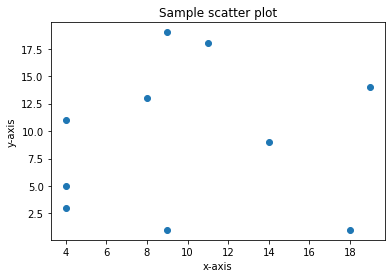

```python
x_data = np.random.randint(20, size=10)
y_data = np.random.randint(20, size=10)

print(f"{x_data=}\n"
      f"{y_data=}\n")

plt.scatter(x_data, y_data)
plt.xlabel("x-axis")
plt.ylabel("y-axis")
plt.title("Sample scatter plot")
#plt.show()
# More info: https://matplotlib.org/stable/api/_as_gen/matplotlib.pyplot.scatter.html
```

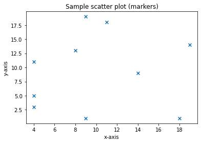

```python
plt.scatter(x_data, y_data, marker='x')
plt.xlabel("x-axis")
plt.ylabel("y-axis")
plt.title("Sample scatter plot (markers)")
#plt.show()
# More info: https://matplotlib.org/stable/api/markers_api.html#module-matplotlib.markers
```

### 4.2 Plotting sine and cosine

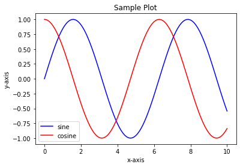

```python
x_data = np.linspace(0,10, 101)# 0, 0.1,0.2...,9.9,10
y_sin_data = np.sin(x_data)
y_cos_data = np.cos(x_data)
plt.plot(x_data, y_sin_data, 'b')
plt.plot(x_data, y_cos_data, 'r')
plt.xlabel("x-axis")
plt.ylabel("y-axis")

plt.legend(['sine', 'cosine'])

plt.title("Sample Plot")
#plt.show()
# More info: https://matplotlib.org/stable/api/markers_api.html#module-matplotlib.markers
```

### 4.3 Plotting image

```
[[ 0  1  2  3  4]
 [ 5  6  7  8  9]
 [10 11 12 13 14]
 [15 16 17 18 19]]
```

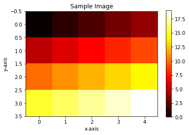

```python
image_arr = np.arange(20).reshape(4,-1)

print(image_arr)

plt.imshow(image_arr, cmap="hot")

# add colorbar
plt.colorbar()

# add title
plt.title("Sample Image")

# add axes labels
plt.xlabel("x-axis")
plt.ylabel("y-axis")

# change extent
# change color
# plt.show()

# More info: https://matplotlib.org/stable/api/_as_gen/matplotlib.pyplot.imshow.html
```

### 4.4 Exercise

**Problem statement**:

- Given a dynamic spectrum of a dispersed pulse, obtain the *off-pulse spectrum*.
- A folded dynamic spectrum of a simulated dispersed pule is given in file: `simulated_pulse.image`.  
  #### Steps
1. Import this data using *`np.loadtxt`*
2. Using *`matplotlib.pyplot.imshow`*, plot this image data. Make sure that the extent along both axes correct:
   - PulsePhase axis: from 0 to 1
   - Frequency: Let's say central frequency is 220 MHz and bandwidth is 20 MHz
3. Add lables and colorbar to the image
4. Note the Pulse Phase range(columns) where the dispersed pulse exists and flag these.
5. Take mean along the pulse phase for each frequency channel to obtain the off-pulse spectrum.
6. Save this off-pulse spectrum using *`np.savetxt`*

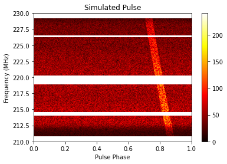

```python
dynanmic_spectrum = np.loadtxt("simulated_pulse.image")

plt.imshow(dynanmic_spectrum,aspect="auto", cmap="hot", extent=[0, 1, 210, 230])
plt.title("Simulated Pulse")
plt.xlabel("Pulse Phase")
plt.ylabel("Frequency (MHz)")
plt.colorbar()
```

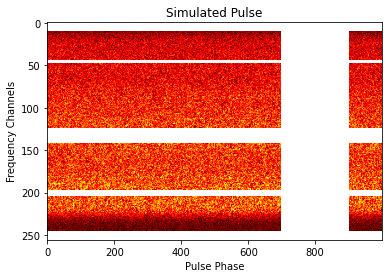

```python
# Flag the pulse
dispersed_pulse_start_phase = 0.7
dispersed_pulse_end_phase = 0.9

dispersed_pulse_start = int(dispersed_pulse_start_phase*1000)
dispersed_pulse_end = int(dispersed_pulse_end_phase*1000)
dynanmic_spectrum[:, dispersed_pulse_start:dispersed_pulse_end] = np.nan

plt.imshow(dynanmic_spectrum,aspect="auto", cmap="hot")
plt.imshow(dynanmic_spectrum,aspect="auto", cmap="hot")
plt.title("Simulated Pulse")
plt.xlabel("Pulse Phase")
plt.ylabel("Frequency Channels")
```

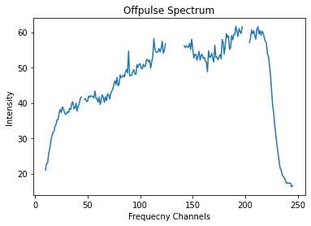

```python
with warnings.catch_warnings():
    warnings.simplefilter("ignore", category=RuntimeWarning)
    offpulse_spectrum = np.nanmean(dynanmic_spectrum, axis=1)

plt.plot(offpulse_spectrum)
plt.title("Offpulse Spectrum")
plt.xlabel("Frequecny Channels")
plt.ylabel("Intensity")

np.savetxt("offpulse_spectrum.dat", offpulse_spectrum)
```